# HW 2

Simay Gökalp

4 Mayıs 2021

## Liquidated Firm Statistics

### Introduction

Liquidated Total (Number) is the number of firms which are gone out of business and their assets sold. This is mostly related to the economic crisis. If the purchasing power of the society decrease, than people don’t spend us much. This will directly affects the profit of the business. If the business cannot make enough profit through sales or the services that they provided, they had to shut down. During the economic crisis exchange rates will increase, the prices are higher which means the price index increase. Also the interest will be increased by TCMB to stop the increase in the currencies. That’s why I will also examine dollar rates and price index. My assumption is the peaks of these parameters will match the increases in the liquidated firms.

As liquidation also means that the business cannot pay their obligations when they are due. The interest rates for the business may effect the payment. If the interest rates are high, than it is possible for many company to not be able to pay their debts. The interest rates will be examined.

I also assumed that there is a reverse relationship between opened business and closed ones. If the economy is good than the new firms will be established and if the economy is shaking not many firms will be willing to enter the system. I expect to see a negative relationship.

As another regressor, I took the total Capital of Liquidated Companies. I expect a really high correlation between the number of liquidated firms and liquidated capital.

I will make a time series regression, so I will check for seasonality and general trend. I am expecting a see seasonality as year ends is critical for accounting activities.

I will examine the autocorrelation of the target variable. For the April, I won’t have some of my regressors value, that’s why I will use 1 month lagged versions of the variables. To decide the best model. I may use target values lagged data if it results well. I will check correlations, try to avoid multicollinearity, errors distribution and graphs. I will end up the model which gives me the highest adjusted R square.

### Data manipulation and Visualization

Activating the required libraries for modeling and visualizations.

```r
library(readxl)
library(data.table)
library(zoo)
library(GGally)
```

```r
library(colorspace)
library(ggplot2)
library(skimr)
library(ggcorrplot)
library(car)
library(fpp)
```

Reading and ordering the data. I am controlling the data type with the str functions.

Both for the target variable and regressors; interest rate, liquidated capital, dollar exchange rate, # of opened firms and price index.

```r
Liquidated <- read_excel("Liquidated.xlsx")
Liquidated <- as.data.table(Liquidated)
names(Liquidated) = c("date", "liquidated")
Liquidated$date <- as.Date(as.yearmon(Liquidated$date))
Liquidated <- Liquidated[order(as.Date(Liquidated$date)),]
str(Liquidated)
```

```
## Classes 'data.table' and 'data.frame':   135 obs. of  2 variables:
##  $ date      : Date, format: "2010-01-01" "2010-02-01" ...
##  $ liquidated: num  1942 1064 989 912 822 ...
##  - attr(*, ".internal.selfref")=<externalptr>
```

```r
dolar <- read_excel("dolar.xlsx")
dolar <- as.data.table(dolar)
dolar$date <- as.Date(as.yearmon(dolar$date))
str(dolar)
```

```
## Classes 'data.table' and 'data.frame':   136 obs. of  2 variables:
##  $ date : Date, format: "2010-01-01" "2010-02-01" ...
##  $ dolar: num  1.47 1.51 1.53 1.49 1.53 ...
##  - attr(*, ".internal.selfref")=<externalptr>
```

```r
interest_rate <- read_excel("interest_rate.xlsx")
interest_rate<- as.data.table(interest_rate)
interest_rate$date <- as.Date(as.yearmon(interest_rate$date))
str(interest_rate)
```

```
## Classes 'data.table' and 'data.frame':   136 obs. of  2 variables:
##  $ date    : Date, format: "2010-01-01" "2010-02-01" ...
##  $ interest: num  9.26 8.83 8.7 9.36 8.9 ...
##  - attr(*, ".internal.selfref")=<externalptr>
```

```r
Liq_Money <- read_excel("Liq_Money.xlsx")
Liq_Money<- as.data.table(Liq_Money)
names(Liq_Money) = c("date", "liq_money")
Liq_Money$date <- as.Date(as.yearmon(Liq_Money$date))
Liq_Money <- Liq_Money[order(as.Date(Liq_Money$date)),]
str(Liq_Money)
```

```
## Classes 'data.table' and 'data.frame':   135 obs. of  2 variables:
##  $ date     : Date, format: "2010-01-01" "2010-02-01" ...
##  $ liq_money: num  1.06e+09 1.09e+09 1.14e+09 9.13e+08 9.99e+08 ...
##  - attr(*, ".internal.selfref")=<externalptr>
```

```r
price_index <- read_excel("price_index.xlsx")
price_index  <- as.data.table(price_index)
names(price_index) = c("date", "price_index")
price_index$date <- as.Date(as.yearmon(price_index$date))
str(price_index)
```

```
## Classes 'data.table' and 'data.frame':   136 obs. of  2 variables:
##  $ date       : Date, format: "2010-01-01" "2010-02-01" ...
##  $ price_index: num  174 177 178 179 178 ...
##  - attr(*, ".internal.selfref")=<externalptr>
```

```r
opened <- read_excel("opened.xlsx")
opened  <- as.data.table(opened)
names(opened) = c("date", "opened")
opened$date <- as.Date(as.yearmon(opened$date))
str(opened)
```

```
## Classes 'data.table' and 'data.frame':   135 obs. of  2 variables:
##  $ date  : Date, format: "2010-01-01" "2010-02-01" ...
##  $ opened: num  5000 4230 5055 4466 4072 ...
##  - attr(*, ".internal.selfref")=<externalptr>
```

After reading the data, we should put it together in one table to analyze and visualize better and to create the linear regression model.

```r
all_data <- Liquidated
all_data <- all_data[,dolar:=dolar$dolar[1:135]]
all_data <- all_data[,interest:=interest_rate$interest[1:135]]
all_data <- all_data[,liq_money:=Liq_Money$liq_money[1:135]]
all_data <- all_data[,opened:=opened$opened[1:135]]
all_data <- all_data[,price_index:=price_index$price_index[1:135]]
```

#### Visualizing the Target Variable

First of all let’s examine the general summary of our data and check whether everything is as it should.

```r
summary_data=skim(all_data)
print(summary_data)
```

```
## -- Data Summary ------------------------
##                            Values
## Name                       all_data
## Number of rows             135
## Number of columns          7
## Key                        NULL
## _______________________
## Column type frequency:
##   Date                     1
##   numeric                  6
## ________________________
## Group variables            None
##
## -- Variable type: Date ---------------------------------------------------------
## # A tibble: 1 x 7
##   skim_variable n_missing complete_rate min        max        median
## * <chr>             <int>         <dbl> <date>     <date>     <date>
## 1 date                  0             1 2010-01-01 2021-03-01 2015-08-01
##   n_unique
## *    <int>
## 1      135
##
## -- Variable type: numeric ------------------------------------------------------
## # A tibble: 6 x 11
##   skim_variable n_missing complete_rate          mean            sd           p0
## * <chr>             <int>         <dbl>         <dbl>         <dbl>        <dbl>
## 1 liquidated            0             1       1221.          560.         427
## 2 dolar                 0             1          3.36          1.87         1.42
## 3 interest              0             1         14.8           5.10         8.41
## 4 liq_money             0             1 2077465211.   2183620668.   364165460
## 5 opened                0             1       5686.         1979.        2393
## 6 price_index           0             1        291.           97.5        174.
##            p25           p50           p75    p100 hist
## *        <dbl>         <dbl>         <dbl>   <dbl> <chr>
## 1       874          1073          1254.   3.18e 3 ▆▇▁▂▁
## 2         1.80          2.83          4.52 8.00e 0 ▇▃▁▂▂
## 3        11.5          14.2          16.1  3.45e 1 ▇▇▁▁▁
## 4 984370708.   1347996371    2278538980    1.83e10 ▇▁▁▁▁
## 5      4339          5275          6780.   1.14e 4 ▅▇▅▂▁
## 6       212.          261.          353.   5.24e 2 ▇▅▂▂▂
```

After a general overview, everything on the data gathering looks fine. Next step, I will check the general trend of my data to create my time series regression.

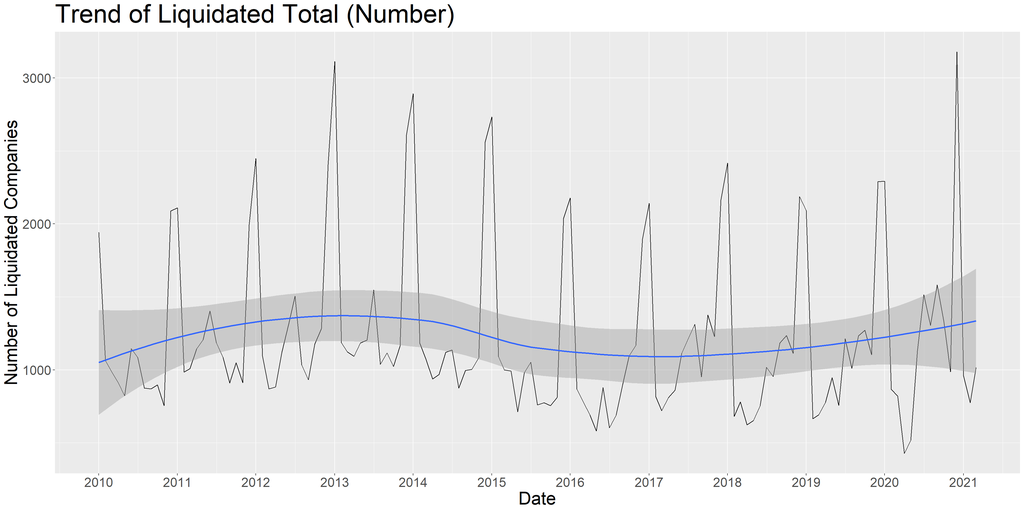

```r
ggplot(all_data, aes(x=date, y=liquidated)) + geom_line() + stat_smooth() +

  xlab("") + scale_x_date(date_breaks = "1 year", date_labels = "%Y") +
  theme(axis.text.x = element_text(size = 18)) + theme(axis.text.y = element_text(size = 18)) +
  xlab("Date") + ylab("Number of Liquidated Companies") + theme(axis.title.x = element_text(size = 25)) + theme(axis.title.y=element_text(size = 25)) + ggtitle("Trend of Liquidated Total (Number)") + theme(title = element_text(size = 30))
```

We don’t see a general increasing or decreasing trend, it is fluctuating over time. The variance is not significantly increasing or decreasing. There is a clear seasonality which will be checked autocorrelation function.

I will control the distribution of the data to check whether it is fitting the normal distribution.

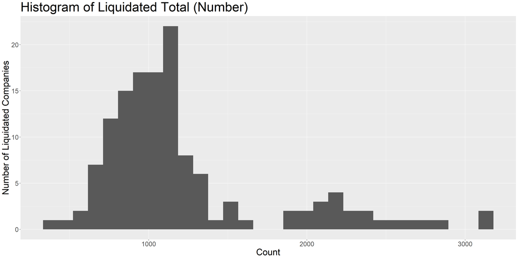

```r
ggplot(all_data, aes(x=liquidated)) + geom_histogram() + xlab("Count") + ylab("Number of Liquidated Companies") + ggtitle("Histogram of Liquidated Total (Number)") + theme(title = element_text(size = 30)) + theme(axis.title.x = element_text(size = 25)) + theme(axis.title.y=element_text(size = 25)) + theme(axis.text.x = element_text(size = 18)) + theme(axis.text.y = element_text(size = 18))
```

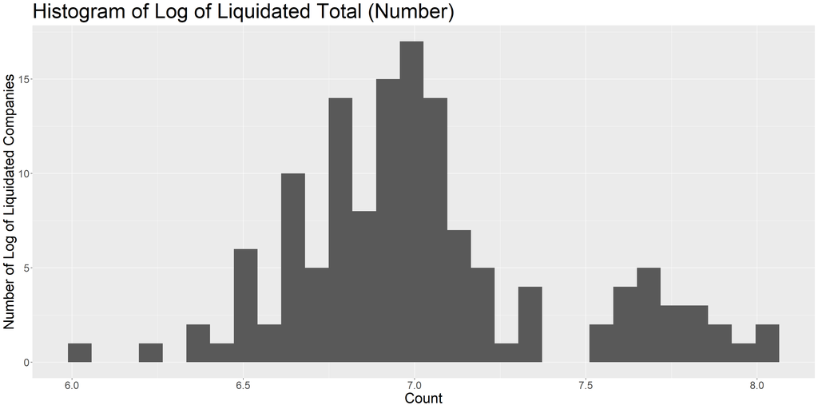

```r
liq_log <- log(all_data$liquidated)

all_data=all_data[,log_liq:=as.numeric(liq_log)]

ggplot(all_data, aes(x=log_liq)) + geom_histogram() + xlab("Count") + ylab("Number of Log of Liquidated Companies") + ggtitle("Histogram of Log of Liquidated Total (Number)") + theme(title = element_text(size = 30)) + theme(axis.title.x = element_text(size = 25)) + theme(axis.title.y=element_text(size = 25)) + theme(axis.text.x = element_text(size = 18)) + theme(axis.text.y = element_text(size = 18))
```

We can see from the graph, log version is better fitting to the normality assumption. Let’s compare them in a Q-Q plot.

```r
qqPlot(all_data$liquidated , ylab = "Liquidated Total (Number)", xlab = "Theoretical Quantities", main = "Q-Q Plot of Liquidated Total (Number)")
```

```
## [1] 132  37
```

```
## [1] 132  37
```

[figure not shown]

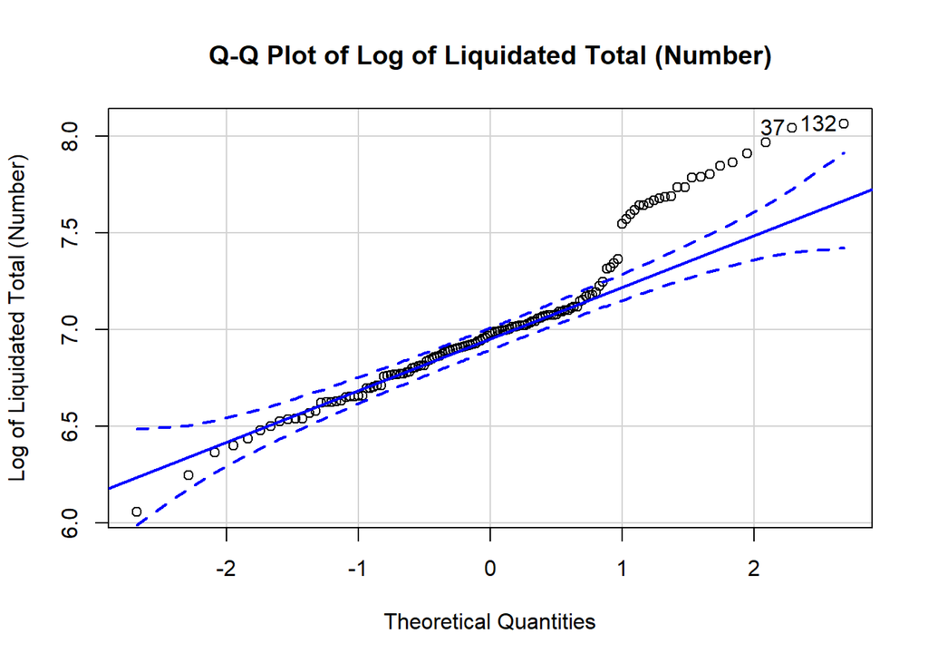

```r
qqPlot(all_data$log_liq, ylab = "Log of Liquidated Total (Number)" , xlab = "Theoretical Quantities", main= "Q-Q Plot of Log of Liquidated Total (Number)")
```

As also Q-Q plots show the log data is more suitable to normal distribution.

Let also examine the log data trend.

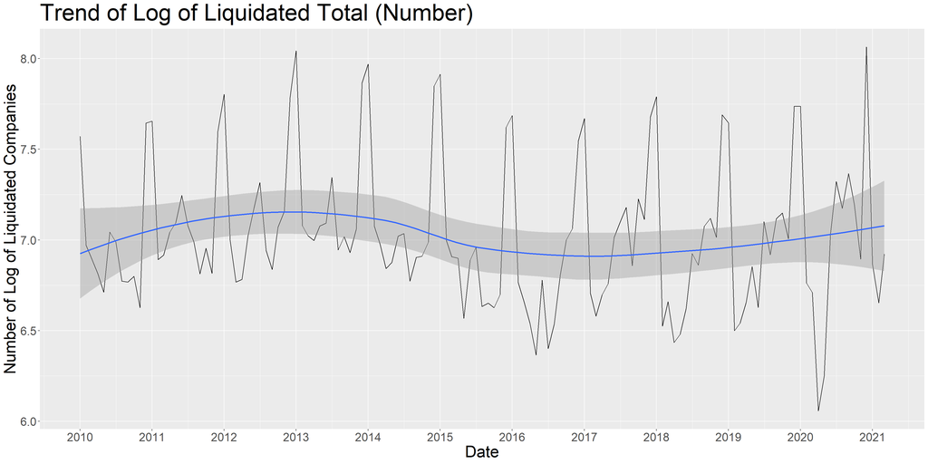

```r
ggplot(all_data, aes(x=date, y=log_liq)) + geom_line() + stat_smooth() +

  xlab("") + scale_x_date(date_breaks = "1 year", date_labels = "%Y") +
  theme(axis.text.x = element_text(size = 18)) + theme(axis.text.y = element_text(size = 18)) +
  xlab("Date") + ylab("Number of Log of Liquidated Companies") + theme(axis.title.x = element_text(size = 25)) + theme(axis.title.y=element_text(size = 25)) + ggtitle("Trend of Log of Liquidated Total (Number)") + theme(title = element_text(size = 30))
```

By this log operations, we decrease the variance even more. The seasonality data is obvious. Let’s check the auto correlation to be sure of the autocorrelation.

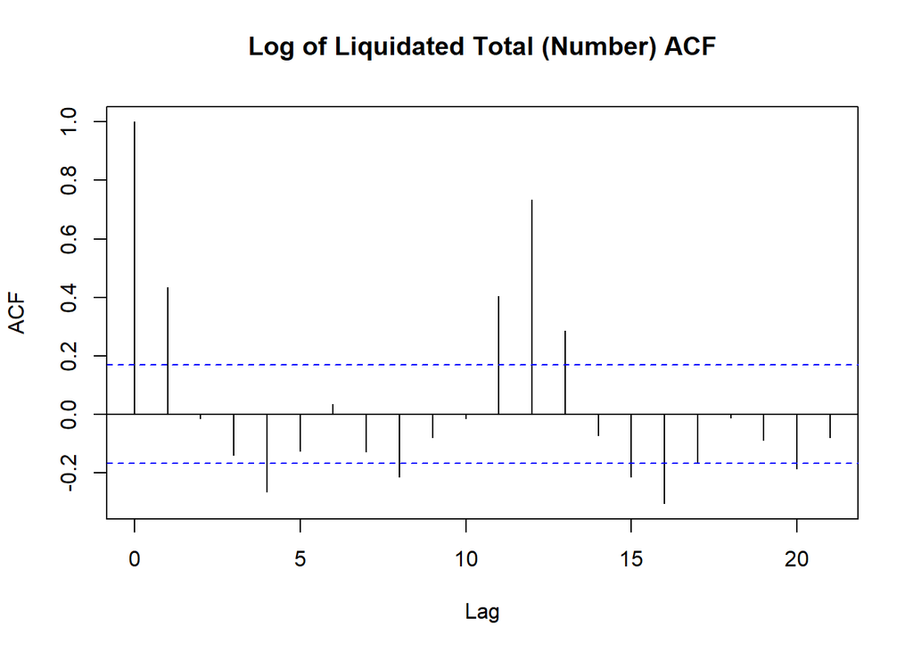

```r
acf(all_data$log_liq, main = "Log of Liquidated Total (Number) ACF")
```

We can see from the autocorrelation which is really high at 12, there is monthly seasonality. Let’s add the seasonality coefficient.

```r
month = seq(1,12,by=1)

all_data = cbind(all_data,month)
```

Let’s also increase the general trend data, although we cannot see a general pattern, let the model decide its effect.

```r
all_data <- all_data[,trend:=1:.N]
```

Let’s also build the time series object of the whole data.

```r
ts_all_data <- ts(all_data, frequency = 12, start = c(2010,1))
```

To decide which parameters to take our model, lets’s examine the correlations. To be able to use ggplot’s correlation function, let’s have on the numeric data, and reduce the date and Liquidated Total (Number) because we will be use log version of it.

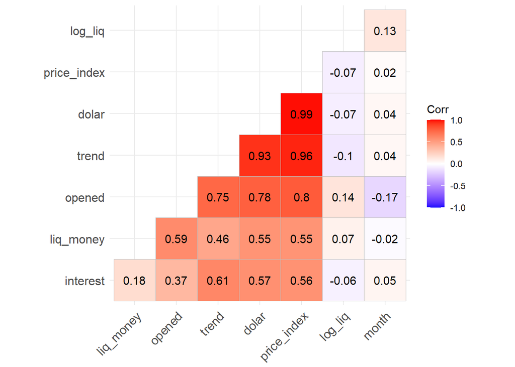

```r
numeric_data <- all_data
numeric_data$date = NULL
numeric_data$liquidated = NULL


correl_info =cor(numeric_data)
ggcorrplot(correl_info, hc.order = TRUE, type = "lower",lab = TRUE)
```

The correlation plot unfortunately tells us there is no strong relationship between regressors and target value. At the introduction I assumed that when dollar gets higher and interest increases, the liquated number of companies can be increased. However, it is revealed from the correlation that it is not the case.

I also expect to see opened # of business will have a negative relationship however, they are irrelevant and on the positive correlation side.

Also dollar, price index and trend have a high correlation, which means if we deduct them from model adjusted R square will increase.

Let’s also check ggpairs to see the visualization of each graphs to one another

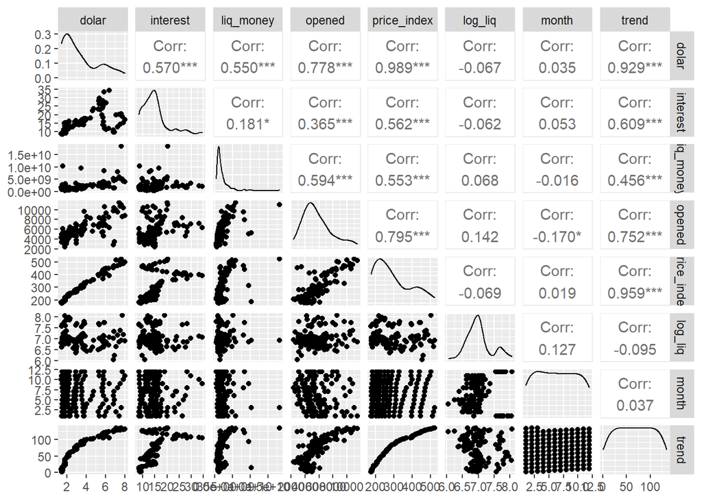

```r
ggpairs(numeric_data)
```

We can see from also the graphs that not have direct relationship with any of the regressors. We also can see the parallelism of dollar rate and price index and trend also from the scatter plots.

Let’s create our model with everything we have and then improve it with the deduction of multicollinarity.

To be able to to it, we need to convert months to a factor variables instead of numeric data.

```r
model1_data <- numeric_data
model1_data$month = as.factor(model1_data$month)
```

BUilding our first model with all parameters:

```r
model=lm(log_liq~.,model1_data)
summary(model)
```

```
##
## Call:
## lm(formula = log_liq ~ ., data = model1_data)
##
## Residuals:
##      Min       1Q   Median       3Q      Max
## -0.84875 -0.13727  0.01529  0.14014  0.41625
##
## Coefficients:
##               Estimate Std. Error t value Pr(>|t|)
## (Intercept)  7.545e+00  2.948e-01  25.592  < 2e-16 ***
## dolar       -5.896e-04  8.410e-02  -0.007  0.99442
## interest     2.087e-03  4.828e-03   0.432  0.66633
## liq_money    1.043e-11  1.190e-11   0.876  0.38287
## opened       5.516e-05  1.838e-05   3.002  0.00328 **
## price_index -3.796e-04  2.201e-03  -0.172  0.86336
## month2      -8.023e-01  8.859e-02  -9.056 3.63e-15 ***
## month3      -8.674e-01  9.069e-02  -9.565 2.31e-16 ***
## month4      -8.950e-01  9.317e-02  -9.607  < 2e-16 ***
## month5      -8.544e-01  9.453e-02  -9.039 3.97e-15 ***
## month6      -6.410e-01  9.417e-02  -6.807 4.52e-10 ***
## month7      -5.325e-01  9.497e-02  -5.607 1.40e-07 ***
## month8      -6.856e-01  9.784e-02  -7.008 1.66e-10 ***
## month9      -6.669e-01  9.711e-02  -6.867 3.35e-10 ***
## month10     -6.076e-01  9.227e-02  -6.586 1.35e-09 ***
## month11     -6.480e-01  9.319e-02  -6.953 2.18e-10 ***
## month12      1.332e-01  9.405e-02   1.416  0.15936
## trend       -2.752e-03  2.224e-03  -1.237  0.21853
## ---
## Signif. codes:  0 '***' 0.001 '**' 0.01 '*' 0.05 '.' 0.1 ' ' 1
##
## Residual standard error: 0.211 on 117 degrees of freedom
## Multiple R-squared:  0.748,  Adjusted R-squared:  0.7114
## F-statistic: 20.43 on 17 and 117 DF,  p-value: < 2.2e-16
```

As we can see from the results month factor has a significant impact to the model and opened # of business is also significant. The trend impacts our model in a general confidence interval.

Let’s visualize our actual data and the trends to see how well it fits.

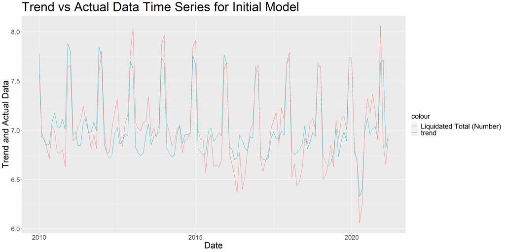

```r
model1_data[,trend_constant:=predict(model,model1_data)]
model1_data[,date:=all_data$date]

ggplot(model1_data, aes(x=date)) + geom_line(aes(y=log_liq)) + geom_line(aes(y=trend_constant,color='trend')) + geom_line(aes(y=log_liq,color='Liquidated Total (Number)')) + xlab("Date") + ylab("Trend and Actual Data") + ggtitle("Trend vs Actual Data Time Series for Initial Model") + theme(title = element_text(size = 30)) + theme(axis.title.x = element_text(size = 25)) + theme(axis.title.y=element_text(size = 25)) + theme(axis.text.x = element_text(size = 18)) + theme(axis.text.y = element_text(size = 18))  + theme(
  legend.title = element_text(size = 20),
  legend.text = element_text(size = 20)
  )
```

Monthly seasonality has helped us a lot to catch with the trend. In 2021 we see a sharp difference between our models prediction and real data. The model over assumed the highest and lowest peaks of the model.

Let’s try to improve our model by reducing the insignificant variables and reduced multicollinarity by using only month, opened and trend data.

```r
model1=lm(log_liq~opened + month + trend, model1_data)
summary(model1)
```

```
##
## Call:
## lm(formula = log_liq ~ opened + month + trend, data = model1_data)
##
## Residuals:
##      Min       1Q   Median       3Q      Max
## -0.85397 -0.14365  0.02531  0.14228  0.41649
##
## Coefficients:
##               Estimate Std. Error t value Pr(>|t|)
## (Intercept)  7.507e+00  9.910e-02  75.756  < 2e-16 ***
## opened       5.744e-05  1.562e-05   3.678 0.000352 ***
## month2      -8.026e-01  8.693e-02  -9.233 1.08e-15 ***
## month3      -8.486e-01  8.606e-02  -9.860  < 2e-16 ***
## month4      -8.937e-01  9.114e-02  -9.806  < 2e-16 ***
## month5      -8.546e-01  9.210e-02  -9.280 8.38e-16 ***
## month6      -6.340e-01  9.151e-02  -6.929 2.21e-10 ***
## month7      -5.277e-01  9.254e-02  -5.703 8.51e-08 ***
## month8      -6.799e-01  9.397e-02  -7.235 4.64e-11 ***
## month9      -6.538e-01  9.209e-02  -7.100 9.28e-11 ***
## month10     -6.057e-01  9.027e-02  -6.710 6.63e-10 ***
## month11     -6.447e-01  9.099e-02  -7.085 1.00e-10 ***
## month12      1.428e-01  9.100e-02   1.569 0.119339
## trend       -3.344e-03  7.516e-04  -4.450 1.92e-05 ***
## ---
## Signif. codes:  0 '***' 0.001 '**' 0.01 '*' 0.05 '.' 0.1 ' ' 1
##
## Residual standard error: 0.2084 on 121 degrees of freedom
## Multiple R-squared:  0.7459, Adjusted R-squared:  0.7186
## F-statistic: 27.32 on 13 and 121 DF,  p-value: < 2.2e-16
```

We obtained a slight improvement in the adjusted R square, however for example our max error is increased slightly. But in general we can say that the model is improved, that’s why we will continue our residual analysis with this model.

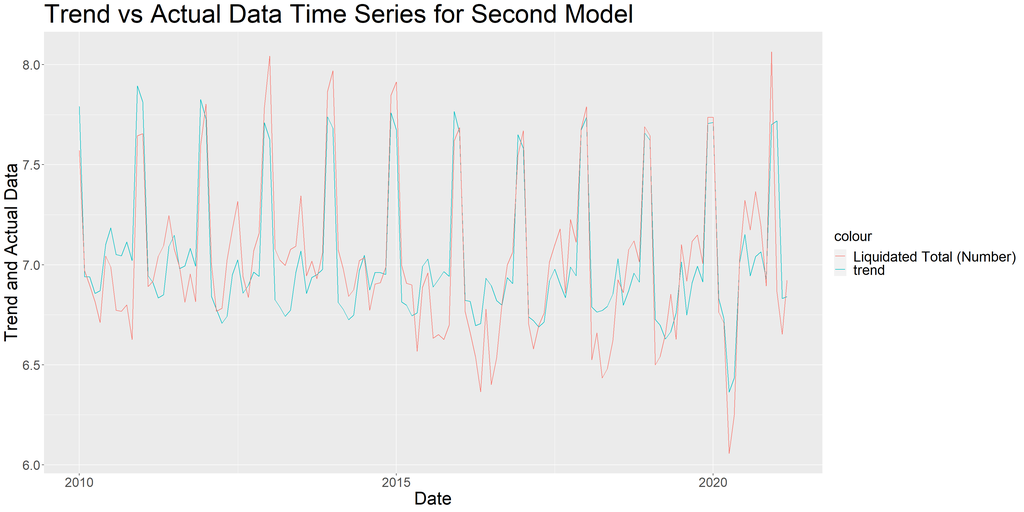

```r
model1_data[,trend_constant1:=predict(model1,model1_data)]
model1_data[,date:=all_data$date]

ggplot(model1_data, aes(x=date)) + geom_line(aes(y=log_liq)) + geom_line(aes(y=trend_constant1,color='trend')) + geom_line(aes(y=log_liq,color='Liquidated Total (Number)')) + xlab("Date") + ylab("Trend and Actual Data") + ggtitle("Trend vs Actual Data Time Series for Second Model") + theme(title = element_text(size = 30)) + theme(axis.title.x = element_text(size = 25)) + theme(axis.title.y=element_text(size = 25)) + theme(axis.text.x = element_text(size = 18)) + theme(axis.text.y = element_text(size = 18))  + theme(
  legend.title = element_text(size = 20),
  legend.text = element_text(size = 20)
  )
```

Monty seasonality has improved our predictions. We don’t seem the extreme guess of the first model which is an improvement. The deep fall in the 04.2020 and the unusual rise in 12.2020 cannot be catched with the model. I believe the fall in 04.2020 is depends on covid realization and government initiatives to support business. And the rise in 12.2020 is long term covid effects on the business, they cannot deal with the crisis without proper government support.

Let’s check residuals of our model.

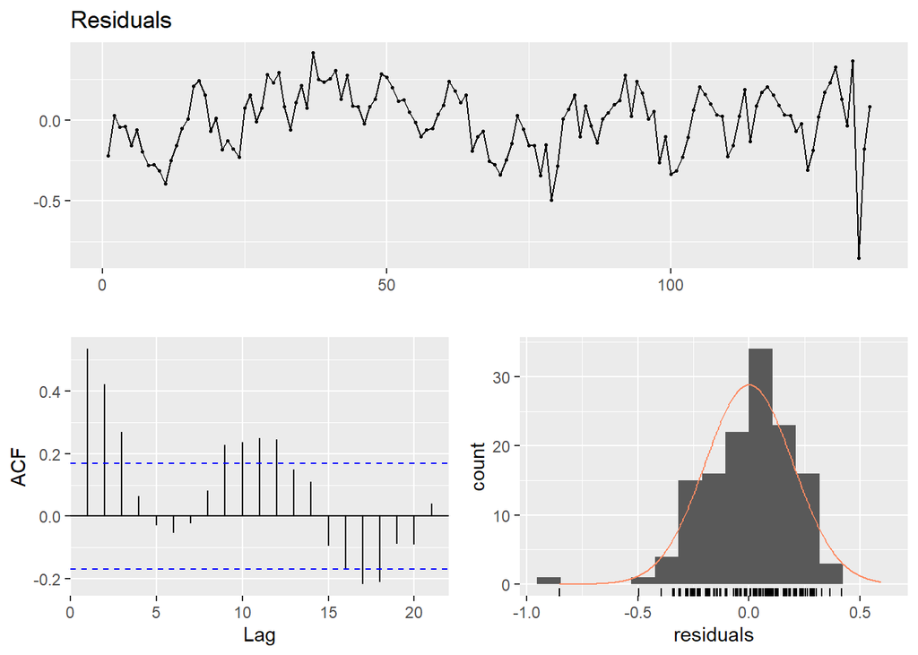

```
##
##  Breusch-Godfrey test for serial correlation of order up to 17
##
## data:  Residuals
## LM test = 65.169, df = 17, p-value = 1.439e-07
```

```r
checkresiduals(model1)
```

```r
mean(model1$residuals)
```

```
## [1] -9.366653e-18
```

Let’s also check the fitted and residuals relation.

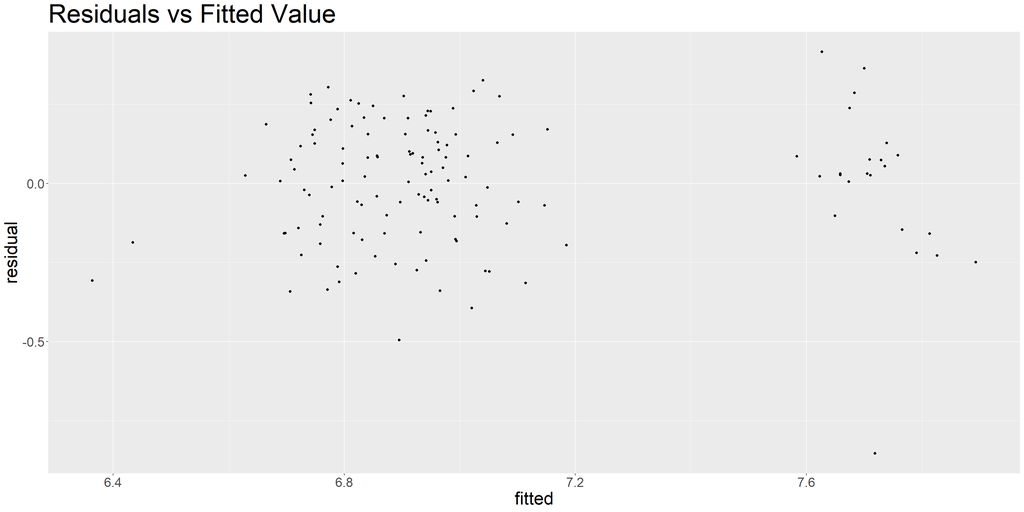

```r
model1_data[,fitted:=fitted(model1)]
model1_data[,residual:=residuals(model1)]

  ggplot(model1_data, aes(x=fitted, y=residual)) +
  geom_point() + ggtitle("Residuals vs Fitted Value") + theme(title = element_text(size = 30)) + theme(axis.title.x = element_text(size = 25)) + theme(axis.title.y=element_text(size = 25)) + theme(axis.text.x = element_text(size = 18)) + theme(axis.text.y = element_text(size = 18))
```

We should see a randomly distrubted scatter plot however, there is two groups of residual here. We may say that fitted and residuals value may have a relationship.

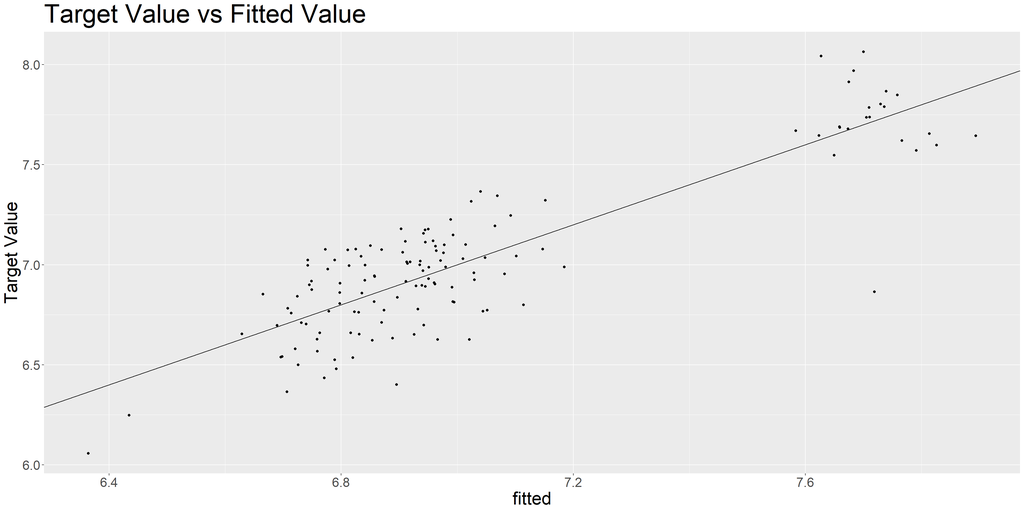

```r
  ggplot(model1_data, aes(x=fitted, y=log_liq)) +
  geom_point() + geom_abline(slope=1, intercept=0) +
  ylab("Target Value") + ggtitle("Target Value vs Fitted Value") + theme(title = element_text(size = 30)) + theme(axis.title.x = element_text(size = 25)) + theme(axis.title.y=element_text(size = 25)) + theme(axis.text.x = element_text(size = 18)) + theme(axis.text.y = element_text(size = 18))
```

Again we can see the grouping, although it should be among the line. So let’s try to improve our model more.

More importantly to improve our cases we will added the lagged version of liquidated data to the model and try to make more accurate model.

```r
lagged_data <- dolar[2:135,]
lagged_data <- lagged_data[,liquidated:=Liquidated$liquidated[2:135]]
lagged_data <- lagged_data[,liq_reg:=Liquidated$liquidated[1:134]] # lagged own data
lagged_data <- lagged_data[,interest:=interest_rate$interest[1:134]]
lagged_data <- lagged_data[,liq_money:=Liq_Money$liq_money[1:134]]
lagged_data <- lagged_data[,opened:=opened$opened[1:134]]
lagged_data <- lagged_data[,price_index:=price_index$price_index[1:134]]

lagged_data <- lagged_data[,trend:=all_data$trend[2:135]]
lagged_data <- lagged_data[,month:=all_data$month[2:135]]
lagged_data$month <- as.factor(lagged_data$month)

liq_log <- log(lagged_data$liquidated)
lagged_data=lagged_data[,log_liq:=as.numeric(liq_log)]

lag_log_lig <- log(lagged_data$liq_reg)
lagged_data=lagged_data[,lag_log_liq:=as.numeric(lag_log_lig )]

lagged_data$date = NULL
lagged_data$liquidated = NULL
lagged_data$liq_reg = NULL
```

Let’s create our model with all these variables first and then remove multicollinarity.

```r
model2=lm(log_liq~.,lagged_data)
summary(model2)
```

```
##
## Call:
## lm(formula = log_liq ~ ., data = lagged_data)
##
## Residuals:
##      Min       1Q   Median       3Q      Max
## -1.01298 -0.09849  0.03877  0.09946  0.36665
##
## Coefficients:
##               Estimate Std. Error t value Pr(>|t|)
## (Intercept)  3.912e+00  6.732e-01   5.811 5.63e-08 ***
## dolar        1.816e-02  6.370e-02   0.285 0.776078
## interest    -1.713e-03  4.237e-03  -0.404 0.686793
## liq_money    2.501e-11  1.371e-11   1.824 0.070739 .
## opened      -4.030e-05  1.745e-05  -2.309 0.022741 *
## price_index  1.765e-04  1.656e-03   0.107 0.915289
## trend       -7.135e-04  1.841e-03  -0.388 0.699059
## month2      -7.879e-01  8.639e-02  -9.120 2.91e-15 ***
## month3      -4.166e-01  1.126e-01  -3.699 0.000334 ***
## month4      -5.006e-01  1.171e-01  -4.274 3.98e-05 ***
## month5      -4.406e-01  1.188e-01  -3.709 0.000322 ***
## month6      -2.308e-01  1.165e-01  -1.981 0.049984 *
## month7      -2.592e-01  1.040e-01  -2.491 0.014156 *
## month8      -4.761e-01  9.914e-02  -4.802 4.78e-06 ***
## month9      -3.575e-01  1.074e-01  -3.327 0.001179 **
## month10     -3.129e-01  1.057e-01  -2.961 0.003729 **
## month11     -3.621e-01  1.028e-01  -3.522 0.000615 ***
## month12      4.393e-01  1.046e-01   4.201 5.28e-05 ***
## lag_log_liq  5.069e-01  8.360e-02   6.063 1.74e-08 ***
## ---
## Signif. codes:  0 '***' 0.001 '**' 0.01 '*' 0.05 '.' 0.1 ' ' 1
##
## Residual standard error: 0.1907 on 115 degrees of freedom
## Multiple R-squared:  0.7946, Adjusted R-squared:  0.7625
## F-statistic: 24.72 on 18 and 115 DF,  p-value: < 2.2e-16
```

There is an impovement in the adjusted R square value and max value is decreased however the min value is a bit more. Let’s abandon the insignificant parameters and rebuild our model.

Given the highest adjusted R squared is obtained with, month, the lagged version of variable itself and opened # of companies.

```r
modelF = lm(log_liq~ month + lag_log_lig + opened + liq_money ,lagged_data)
summary(modelF)
```

```
##
## Call:
## lm(formula = log_liq ~ month + lag_log_lig + opened + liq_money,
##     data = lagged_data)
##
## Residuals:
##      Min       1Q   Median       3Q      Max
## -0.98277 -0.09339  0.02930  0.09288  0.40168
##
## Coefficients:
##               Estimate Std. Error t value Pr(>|t|)
## (Intercept)  3.981e+00  5.953e-01   6.686 7.84e-10 ***
## month2      -7.967e-01  8.147e-02  -9.780  < 2e-16 ***
## month3      -4.241e-01  1.052e-01  -4.033 9.76e-05 ***
## month4      -5.152e-01  1.081e-01  -4.764 5.42e-06 ***
## month5      -4.465e-01  1.124e-01  -3.972 0.000123 ***
## month6      -2.350e-01  1.111e-01  -2.116 0.036441 *
## month7      -2.660e-01  9.977e-02  -2.666 0.008748 **
## month8      -4.778e-01  9.583e-02  -4.985 2.13e-06 ***
## month9      -3.582e-01  1.034e-01  -3.465 0.000738 ***
## month10     -3.198e-01  1.013e-01  -3.157 0.002019 **
## month11     -3.671e-01  9.827e-02  -3.736 0.000289 ***
## month12      4.343e-01  1.003e-01   4.332 3.11e-05 ***
## lag_log_lig  4.970e-01  7.635e-02   6.509 1.88e-09 ***
## opened      -3.373e-05  1.132e-05  -2.981 0.003488 **
## liq_money    2.929e-11  1.269e-11   2.308 0.022720 *
## ---
## Signif. codes:  0 '***' 0.001 '**' 0.01 '*' 0.05 '.' 0.1 ' ' 1
##
## Residual standard error: 0.1883 on 119 degrees of freedom
## Multiple R-squared:  0.7929, Adjusted R-squared:  0.7686
## F-statistic: 32.55 on 14 and 119 DF,  p-value: < 2.2e-16
```

This is the combination that gives the highest adjused R value and it makes logical sense. Let’s visualize and repeat our previous error analysis. We can see that last month has a positive effect. As I expected in the indroduction, opened number of businesses has a negative slop and liquidated money has positive slot.

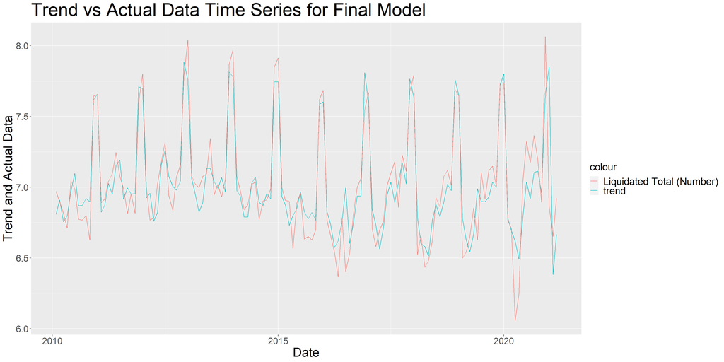

```r
lagged_data[,trend_constant1:=predict(modelF,lagged_data)]
lagged_data[,date:=all_data$date[2:135]]

ggplot(lagged_data, aes(x=date)) + geom_line(aes(y=log_liq)) + geom_line(aes(y=trend_constant1,color='trend')) + geom_line(aes(y=log_liq,color='Liquidated Total (Number)')) + xlab("Date") + ylab("Trend and Actual Data") + ggtitle("Trend vs Actual Data Time Series for Final Model") + theme(title = element_text(size = 30)) + theme(axis.title.x = element_text(size = 25)) + theme(axis.title.y=element_text(size = 25)) + theme(axis.text.x = element_text(size = 18)) + theme(axis.text.y = element_text(size = 18))  + theme(
  legend.title = element_text(size = 20),
  legend.text = element_text(size = 20)
  )
```

The model cannot solve the explanation problem in 04.2020. This low number is only due to a specific event so we can say it is normal. We see a better estimated peaks at the end of year period, this shows that our model has improved.

Let’s check residuals.

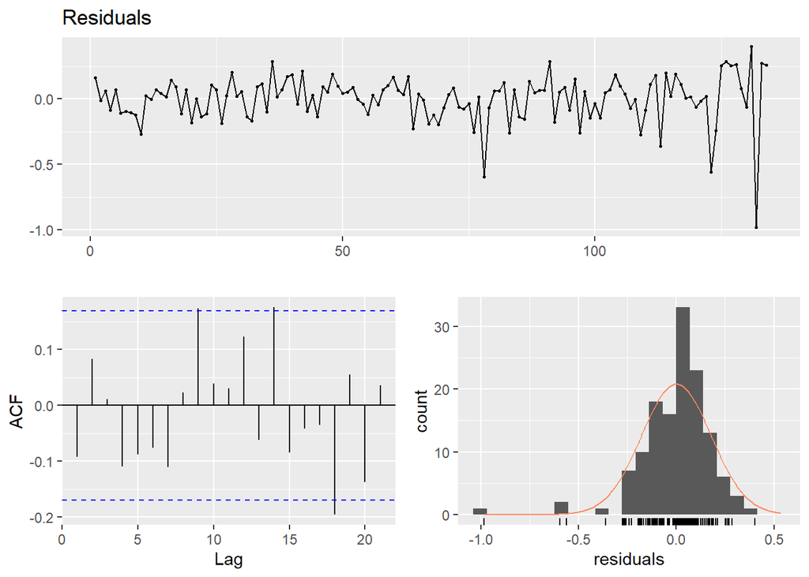

```
##
##  Breusch-Godfrey test for serial correlation of order up to 18
##
## data:  Residuals
## LM test = 43.766, df = 18, p-value = 0.0006231
```

```r
checkresiduals(modelF)
```

```r
mean(modelF$residuals)
```

```
## [1] 3.054376e-19
```

The mean of residuals are very closed to 0. Autocorrelation of the residuals has drop drasticcally. However, the residuals are not fit completely to the normal plot when compared to the previous models.

Let’s also check the residuals vs fitted plot to understand our model dynamics better.

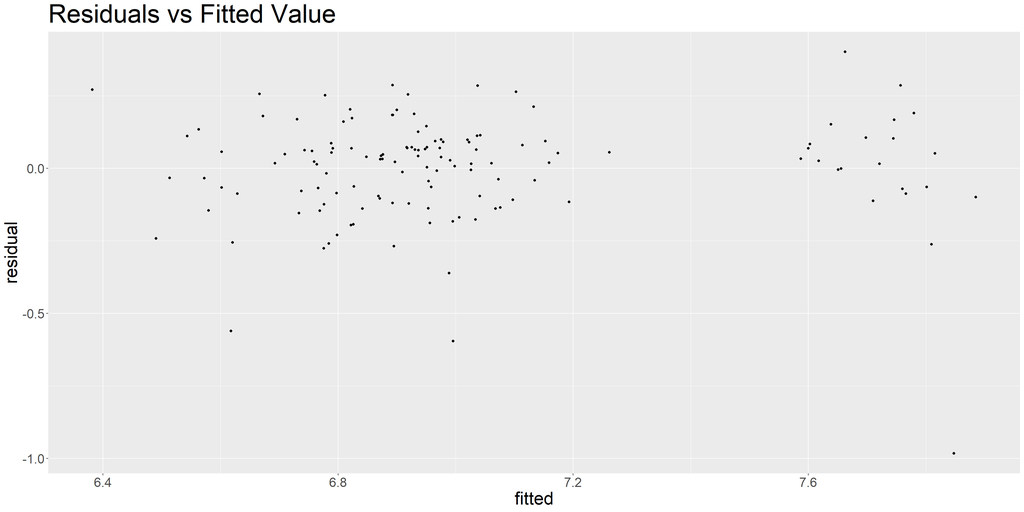

```r
lagged_data[,fitted:=fitted(modelF)]
lagged_data[,residual:=residuals(modelF)]

  ggplot(lagged_data, aes(x=fitted, y=residual)) +
  geom_point() + ggtitle("Residuals vs Fitted Value") + theme(title = element_text(size = 30)) + theme(axis.title.x = element_text(size = 25)) + theme(axis.title.y=element_text(size = 25)) + theme(axis.text.x = element_text(size = 18)) + theme(axis.text.y = element_text(size = 18))
```

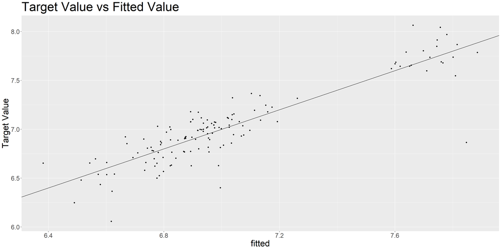

```r
  ggplot(lagged_data, aes(x=fitted, y=log_liq)) +
  geom_point() +
  geom_abline(slope=1, intercept=0) +  ylab("Target Value") + ggtitle("Target Value vs Fitted Value") + theme(title = element_text(size = 30)) + theme(axis.title.x = element_text(size = 25)) + theme(axis.title.y=element_text(size = 25)) + theme(axis.text.x = element_text(size = 18)) + theme(axis.text.y = element_text(size = 18))
```

There is alo an improvemnet here compared to the previous model. As we expected the residuals are mostly around x=y line.

#### Prediction for April

I will take the regressor values in below and put all of them in an empty data table. Then, I will make the prediction for April with my final model. Month = 4 Lag_log_lig = 6.922644 Opened = 11034 Liq_money = 18277240070

```r
x <- cbind(4,6.922644,11034,18277240070)
x <- as.data.table(x)
names(x) = c("month", "lag_log_lig", "opened", "liq_money")
x$month <- as.factor(x$month)
```

```r
p <- predict(modelF, x)
print(p)
```

```
##        1
## 7.068848
```

This is the log value, so let’s take the exponential for the final value.

```r
print(exp(p))
```

```
##        1
## 1174.794
```

My guess is on April, 1175 business will be liquidated.

### CONCLUSION

I build a model and improved it than compare the adjusted R quared results. In the final model we use Monthly trend, the lagged version of log liquidate variable, opened number of business and total liquidated capital. Month 12 has a positive effect on the model, which is an important characteristics of the model.

In the end I made my estimation as 1175 and I will compare it to the actual number when the statistics are announced.